```python
#Configuraciones de Python
import pandas as pd
pd.options.display.max_rows = 10
```

[figure not shown]

```python
from IPython.display import Image
Image(filename='/Users/oldemarrodriguez/Google Drive/MDCurso/Datos/logo_python3.png')
```

# Árboles de Decición - Método CART

## Se debe instalar el paquete graphviz

#### En Mac (Terminal):

pip install graphviz

conda install graphviz

#### En Windows (Anaconda Prompt):

pip install graphviz

conda install graphviz

```python
import os
import graphviz # Debe instalar este paquete
import numpy as np
import pandas as pd
import matplotlib.pyplot as plt
import matplotlib.image as mpimg
from matplotlib import colors as mcolors
from sklearn.model_selection import train_test_split
from sklearn.tree import DecisionTreeClassifier
from sklearn.metrics import confusion_matrix
from sklearn.tree import export_graphviz
from pandas import DataFrame
import seaborn as sns
```

## Función para calcular los índices de calidad de la predicción

```python
def indices_general(MC, nombres = None):
    precision_global = np.sum(MC.diagonal()) / np.sum(MC)
    error_global = 1 - precision_global
    precision_categoria  = pd.DataFrame(MC.diagonal()/np.sum(MC,axis = 1)).T
    if nombres!=None:
        precision_categoria.columns = nombres
    return {"Matriz de Confusión":MC,
            "Precisión Global":precision_global,
            "Error Global":error_global,
            "Precisión por categoría":precision_categoria}
```

### Función para graficar la distribución de la variable a predecir

```python
def distribucion_variable_predecir(data:DataFrame,variable_predict:str):
    colors = list(dict(**mcolors.CSS4_COLORS))
    df = pd.crosstab(index=data[variable_predict],columns="valor") / data[variable_predict].count()
    fig = plt.figure(figsize=(10,9))
    g = fig.add_subplot(111)
    countv = 0
    titulo = "Distribución de la variable %s" % variable_predict
    for i in range(df.shape[0]):
        g.barh(1,df.iloc[i],left = countv, align='center',color=colors[11+i],label= df.iloc[i].name)
        countv = countv + df.iloc[i]
    vals = g.get_xticks()
    g.set_xlim(0,1)
    g.set_yticklabels("")
    g.set_title(titulo)
    g.set_ylabel(variable_predict)
    g.set_xticklabels(['{:.0%}'.format(x) for x in vals])
    countv = 0
    for v in df.iloc[:,0]:
        g.text(np.mean([countv,countv+v]) - 0.03, 1 , '{:.1%}'.format(v), color='black', fontweight='bold')
        countv = countv + v
    g.legend(loc='upper center', bbox_to_anchor=(1.08, 1), shadow=True, ncol=1)
```

### Funciones para ver la distribución de una variable respecto a la predecir (poder predictivo)

##### Función para ver la distribución de una variable categórica respecto a la predecir

```python
def poder_predictivo_categorica(data:DataFrame, var:str, variable_predict:str):
    df = pd.crosstab(index= data[var],columns=data[variable_predict])
    df = df.div(df.sum(axis=1),axis=0)
    titulo = "Distribución de la variable %s según la variable %s" % (var,variable_predict)
    g = df.plot(kind='barh',stacked=True,legend = True, figsize = (10,9), \
                xlim = (0,1),title = titulo, width = 0.8)
    vals = g.get_xticks()
    g.set_xticklabels(['{:.0%}'.format(x) for x in vals])
    g.legend(loc='upper center', bbox_to_anchor=(1.08, 1), shadow=True, ncol=1)
    for bars in g.containers:
        plt.setp(bars, width=.9)
    for i in range(df.shape[0]):
        countv = 0
        for v in df.iloc[i]:
            g.text(np.mean([countv,countv+v]) - 0.03, i , '{:.1%}'.format(v), color='black', fontweight='bold')
            countv = countv + v
```

##### Función para ver la distribución de una variable numérica respecto a la predecir

```python
def poder_predictivo_numerica(data:DataFrame, var:str, variable_predict:str):
    sns.FacetGrid(data, hue=variable_predict, height=6).map(sns.kdeplot, var, shade=True).add_legend()
```

## Ejemplo con los datos de Iris

```python
os.chdir("/Users/oldemarrodriguez/Google Drive/MDCurso/Datos")
print(os.getcwd())
datos = pd.read_csv('iris.csv',delimiter=';',decimal=".")
print(datos.shape)
print(datos.head())
print(datos.info())
```

```
/Users/oldemarrodriguez/Google Drive/MDCurso/Datos
(150, 5)
   s.largo  s.ancho  p.largo  p.ancho    tipo
0      5.1      3.5      1.4      0.2  setosa
1      4.9      3.0      1.4      0.2  setosa
2      4.7      3.2      1.3      0.2  setosa
3      4.6      3.1      1.5      0.2  setosa
4      5.0      3.6      1.4      0.2  setosa
<class 'pandas.core.frame.DataFrame'>
RangeIndex: 150 entries, 0 to 149
Data columns (total 5 columns):
s.largo    150 non-null float64
s.ancho    150 non-null float64
p.largo    150 non-null float64
p.ancho    150 non-null float64
tipo       150 non-null object
dtypes: float64(4), object(1)
memory usage: 6.0+ KB
None
```

### Distribución de la variable a predecir

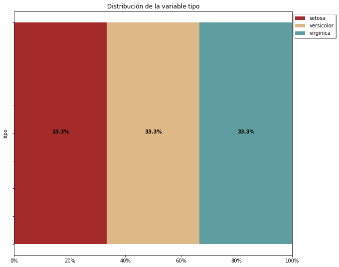

```python
distribucion_variable_predecir(datos,"tipo")
```

### Elimina la variable catégorica, deja las variables predictoras en X

```python
X = datos.iloc[:,:4]
print(X.head())
```

```
   s.largo  s.ancho  p.largo  p.ancho
0      5.1      3.5      1.4      0.2
1      4.9      3.0      1.4      0.2
2      4.7      3.2      1.3      0.2
3      4.6      3.1      1.5      0.2
4      5.0      3.6      1.4      0.2
```

### Deja la variable a predecir en y

```python
y = datos.iloc[:,4:5]
print(y.head())
```

```
     tipo
0  setosa
1  setosa
2  setosa
3  setosa
4  setosa
```

### Se separan los datos con el 70% de los datos para entrenamiento y el 30% para testing

```python
X_train, X_test, y_train, y_test = train_test_split(X, y, train_size=0.7, random_state=0)
```

```python
instancia_arbol = DecisionTreeClassifier(random_state=0)
```

### Entrena el modelo llamando al método fit

**Nota:** Observe que no hay variable que guarde el modelo como en R, esto se debe a que al ser Python Orientado a Objetos, el modelo queda en un atributo de la instancia "instancia_arbol"

```python
instancia_arbol.fit(X_train,y_train)
```

```
DecisionTreeClassifier(class_weight=None, criterion='gini', max_depth=None,
                       max_features=None, max_leaf_nodes=None,
                       min_impurity_decrease=0.0, min_impurity_split=None,
                       min_samples_leaf=1, min_samples_split=2,
                       min_weight_fraction_leaf=0.0, presort=False,
                       random_state=0, splitter='best')
```

#### Imprime las predicciones en testing

```python
print("Las predicciones en Testing son: {}".format(instancia_arbol.predict(X_test)))
```

```
Las predicciones en Testing son: ['virginica' 'versicolor' 'setosa' 'virginica' 'setosa' 'virginica'
 'setosa' 'versicolor' 'versicolor' 'versicolor' 'virginica' 'versicolor'
 'versicolor' 'versicolor' 'versicolor' 'setosa' 'versicolor' 'versicolor'
 'setosa' 'setosa' 'virginica' 'versicolor' 'setosa' 'setosa' 'virginica'
 'setosa' 'setosa' 'versicolor' 'versicolor' 'setosa' 'virginica'
 'versicolor' 'setosa' 'virginica' 'virginica' 'versicolor' 'setosa'
 'virginica' 'versicolor' 'versicolor' 'virginica' 'setosa' 'virginica'
 'setosa' 'setosa']
```

### Índices de Calidad del Modelo

```python
prediccion = instancia_arbol.predict(X_test)
MC = confusion_matrix(y_test, prediccion)
indices = indices_general(MC,list(np.unique(y)))
for k in indices:
    print("\n%s:\n%s"%(k,str(indices[k])))
```

```
Matriz de Confusión:
[[16  0  0]
 [ 0 17  1]
 [ 0  0 11]]

Precisión Global:
0.9777777777777777

Error Global:
0.022222222222222254

Precisión por categoría:
   setosa  versicolor  virginica
0     1.0    0.944444        1.0
```

## Graficando el árbol

### Función para mostrar graficar el árbol

```python
def graficar_arbol(grafico = None):
    grafico.format = "png"
    archivo  = grafico.render()
    img = mpimg.imread(archivo)
    imgplot = plt.imshow(img)
    plt.axis('off')
```

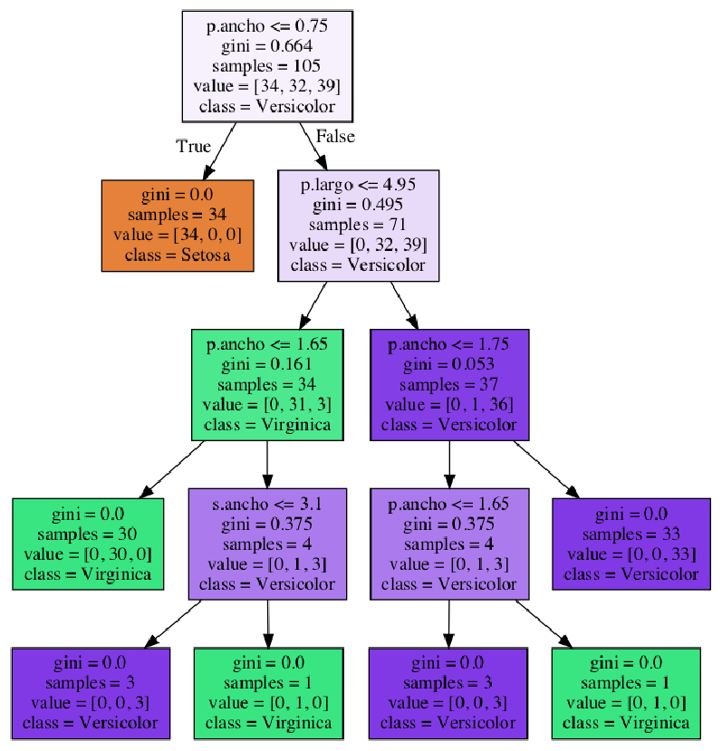

```python
datos_plotear = export_graphviz(instancia_arbol, out_file=None,class_names=["Setosa", "Virginica", "Versicolor"],
                feature_names=list(X.columns.values), filled=True)
grafico = graphviz.Source(datos_plotear)
plt.rcParams['figure.figsize'] = [15, 15] # Tamaño del gráfico
graficar_arbol(grafico)
```

### Ejecución con otros parámetros

```python
# Para ver los parámetros del modelo
DecisionTreeClassifier()
```

```
DecisionTreeClassifier(class_weight=None, criterion='gini', max_depth=None,
                       max_features=None, max_leaf_nodes=None,
                       min_impurity_decrease=0.0, min_impurity_split=None,
                       min_samples_leaf=1, min_samples_split=2,
                       min_weight_fraction_leaf=0.0, presort=False,
                       random_state=None, splitter='best')
```

```python
instancia_arbol2 = DecisionTreeClassifier(criterion='entropy',max_depth=2)
instancia_arbol2.fit(X_train,y_train)
prediccion = instancia_arbol2.predict(X_test)
MC = confusion_matrix(y_test, prediccion)
indices = indices_general(MC,list(np.unique(y)))
for k in indices:
    print("\n%s:\n%s"%(k,str(indices[k])))
```

```
Matriz de Confusión:
[[16  0  0]
 [ 0 17  1]
 [ 0  3  8]]

Precisión Global:
0.9111111111111111

Error Global:
0.0888888888888889

Precisión por categoría:
   setosa  versicolor  virginica
0     1.0    0.944444   0.727273
```

### Graficando el árbol

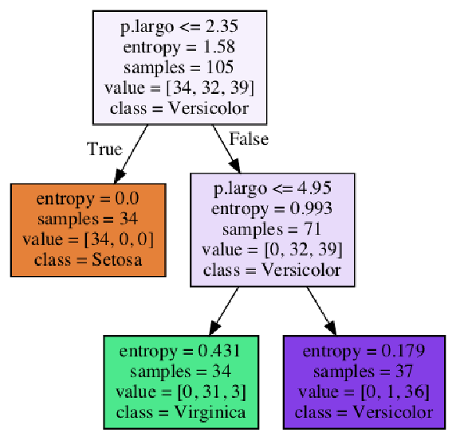

```python
datos_plotear = export_graphviz(instancia_arbol2, out_file=None,class_names=["Setosa", "Virginica", "Versicolor"],
                feature_names=list(X.columns.values), filled=True)
grafico = graphviz.Source(datos_plotear)
plt.rcParams['figure.figsize'] = [10, 10] # Tamaño del gráfico
graficar_arbol(grafico)
```

### Selección de Variables - Análisis del poder predictivo de cada una de las variables predictoras

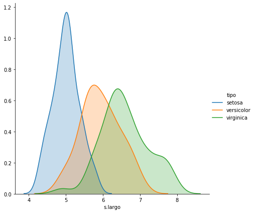

```python
poder_predictivo_numerica(datos,"s.largo","tipo")
```

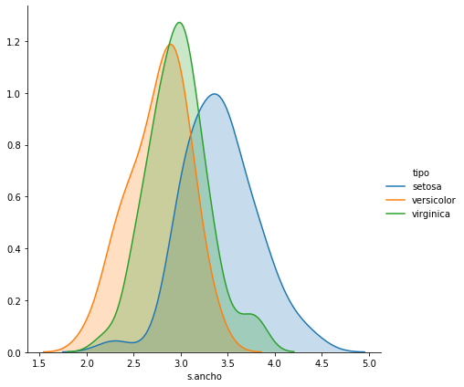

```python
poder_predictivo_numerica(datos,"s.ancho","tipo")
```

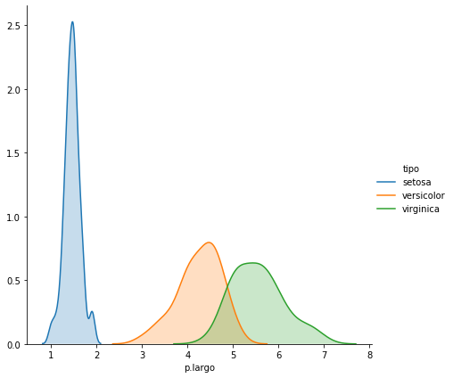

```python
poder_predictivo_numerica(datos,"p.largo","tipo")
```

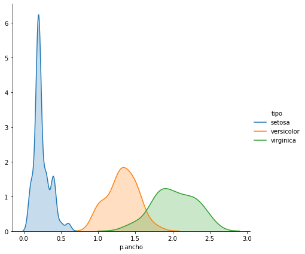

```python
poder_predictivo_numerica(datos,"p.ancho","tipo")
```

#### Elimina la variable categórica, deja como variables predictoras en X al p.largo y p.ancho y deja la variable a predecir en y

```python
X = datos.iloc[:,2:4]
print(X.head())
y = datos.iloc[:,4:5]
print(y.head())
```

```
   p.largo  p.ancho
0      1.4      0.2
1      1.4      0.2
2      1.3      0.2
3      1.5      0.2
4      1.4      0.2
     tipo
0  setosa
1  setosa
2  setosa
3  setosa
4  setosa
```

#### Genera las tablas de training y testing con el 70% de los datos para entrenamiento

```python
X_train, X_test, y_train, y_test = train_test_split(X, y, train_size=0.7, random_state=0)
```

### Generamos el modelos, las predicciones y medimos la calidad de las mismas

```python
instancia_arbol3 = DecisionTreeClassifier()
instancia_arbol3.fit(X_train,y_train)
prediccion = instancia_arbol3.predict(X_test)
MC = confusion_matrix(y_test, prediccion)
indices = indices_general(MC,list(np.unique(y)))
for k in indices:
    print("\n%s:\n%s"%(k,str(indices[k])))
```

```
Matriz de Confusión:
[[16  0  0]
 [ 0 17  1]
 [ 0  1 10]]

Precisión Global:
0.9555555555555556

Error Global:
0.0444444444444444

Precisión por categoría:
   setosa  versicolor  virginica
0     1.0    0.944444   0.909091
```

#### Graficando el árbol

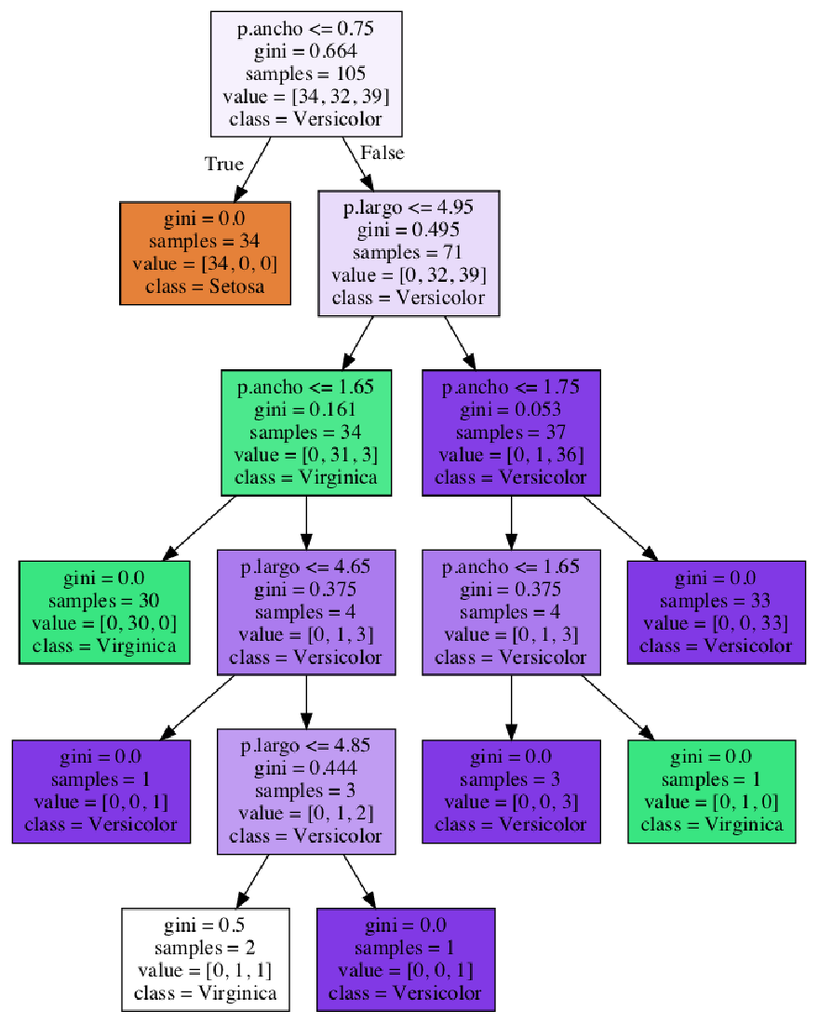

```python
datos_plotear = export_graphviz(instancia_arbol3, out_file=None,class_names=["Setosa", "Virginica", "Versicolor"],
                feature_names=list(X.columns.values), filled=True)
grafico = graphviz.Source(datos_plotear)
plt.rcParams['figure.figsize'] = [20, 20] # Tamaño del gráfico
graficar_arbol(grafico)
```

## Ejemplo Scoring de Crédito

```python
os.chdir("/Users/oldemarrodriguez/Google Drive/MDCurso/Datos")
datos = pd.read_csv('MuestraCredito5000V2.csv',delimiter=';',decimal=".")
print(datos.shape)
print(datos.info())
```

```
(5000, 6)
<class 'pandas.core.frame.DataFrame'>
RangeIndex: 5000 entries, 0 to 4999
Data columns (total 6 columns):
MontoCredito         5000 non-null int64
IngresoNeto          5000 non-null int64
CoefCreditoAvaluo    5000 non-null int64
MontoCuota           5000 non-null object
GradoAcademico       5000 non-null object
BuenPagador          5000 non-null object
dtypes: int64(3), object(3)
memory usage: 234.5+ KB
None
```

**Nota:** Está tomando erroneamente los datos como numéricos, en este caso se deben convertir las variables ccategóricas porque en realidad estos numéros son códigos NO es que siempre se deban convertir las variables numéricas a categórica.

```python
# Convierte las variables de object a categórica
datos['IngresoNeto'] = datos['IngresoNeto'].astype('category')
datos['CoefCreditoAvaluo'] = datos['CoefCreditoAvaluo'].astype('category')
datos['MontoCuota'] = datos['MontoCuota'].astype('category')
datos['GradoAcademico'] = datos['GradoAcademico'].astype('category')
# Recodifica las categorías usando números
datos["MontoCuota"] = datos["MontoCuota"].cat.codes
datos["GradoAcademico"] = datos["GradoAcademico"].cat.codes
# Convierte las variables de entero a categórica
datos['MontoCuota'] = datos['MontoCuota'].astype('category')
datos['GradoAcademico'] = datos['GradoAcademico'].astype('category')
print(datos.head())
print(datos.info())
```

```
   MontoCredito IngresoNeto CoefCreditoAvaluo MontoCuota GradoAcademico  \
0         14327           1                 1          3              0
1        111404           1                 1          3              0
2         21128           1                 1          3              0
3         15426           2                 1          3              0
4         10351           1                 1          3              0

  BuenPagador
0          Si
1          Si
2          Si
3          Si
4          Si
<class 'pandas.core.frame.DataFrame'>
RangeIndex: 5000 entries, 0 to 4999
Data columns (total 6 columns):
MontoCredito         5000 non-null int64
IngresoNeto          5000 non-null category
CoefCreditoAvaluo    5000 non-null category
MontoCuota           5000 non-null category
GradoAcademico       5000 non-null category
BuenPagador          5000 non-null object
dtypes: category(4), int64(1), object(1)
memory usage: 98.6+ KB
None
```

### Balance de las clases en la variable a predecir - Problema desvalanceado

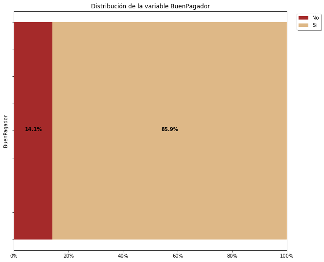

```python
distribucion_variable_predecir(datos,"BuenPagador")
```

### Prepara las tablas de datos

```python
X = datos.iloc[:,:5]
print(X.head())
y = datos.iloc[:,5:6]
print(y.head())
X_train, X_test, y_train, y_test = train_test_split(X, y, train_size=0.75, random_state=0)
```

```
   MontoCredito IngresoNeto CoefCreditoAvaluo MontoCuota GradoAcademico
0         14327           1                 1          3              0
1        111404           1                 1          3              0
2         21128           1                 1          3              0
3         15426           2                 1          3              0
4         10351           1                 1          3              0
  BuenPagador
0          Si
1          Si
2          Si
3          Si
4          Si
```

### Genera el modelo, las predicciones y mide la calidad de las mismas

```python
instancia_arbol = DecisionTreeClassifier()
instancia_arbol.fit(X_train,y_train)
prediccion = instancia_arbol.predict(X_test)
MC = confusion_matrix(y_test, prediccion)
indices = indices_general(MC,list(np.unique(y)))
for k in indices:
    print("\n%s:\n%s"%(k,str(indices[k])))
```

```
Matriz de Confusión:
[[ 117   49]
 [  48 1036]]

Precisión Global:
0.9224

Error Global:
0.0776

Precisión por categoría:
         No       Si
0  0.704819  0.95572
```

### Grafica el árbol

[figure not shown]

```python
datos_plotear = export_graphviz(instancia_arbol, out_file=None,class_names=["No", "Si"],
                feature_names=list(X.columns.values), filled=True)
grafico = graphviz.Source(datos_plotear)
graficar_arbol(grafico)
```

### Podar el árbol

```python
instancia_arbol2 = DecisionTreeClassifier(min_samples_leaf=150)
instancia_arbol2.fit(X_train,y_train)
prediccion = instancia_arbol2.predict(X_test)
MC = confusion_matrix(y_test, prediccion)
indices = indices_general(MC,list(np.unique(y)))
for k in indices:
    print("\n%s:\n%s"%(k,str(indices[k])))
```

```
Matriz de Confusión:
[[  90   76]
 [  26 1058]]

Precisión Global:
0.9184

Error Global:
0.0816

Precisión por categoría:
         No        Si
0  0.542169  0.976015
```

### Graficar el árbol

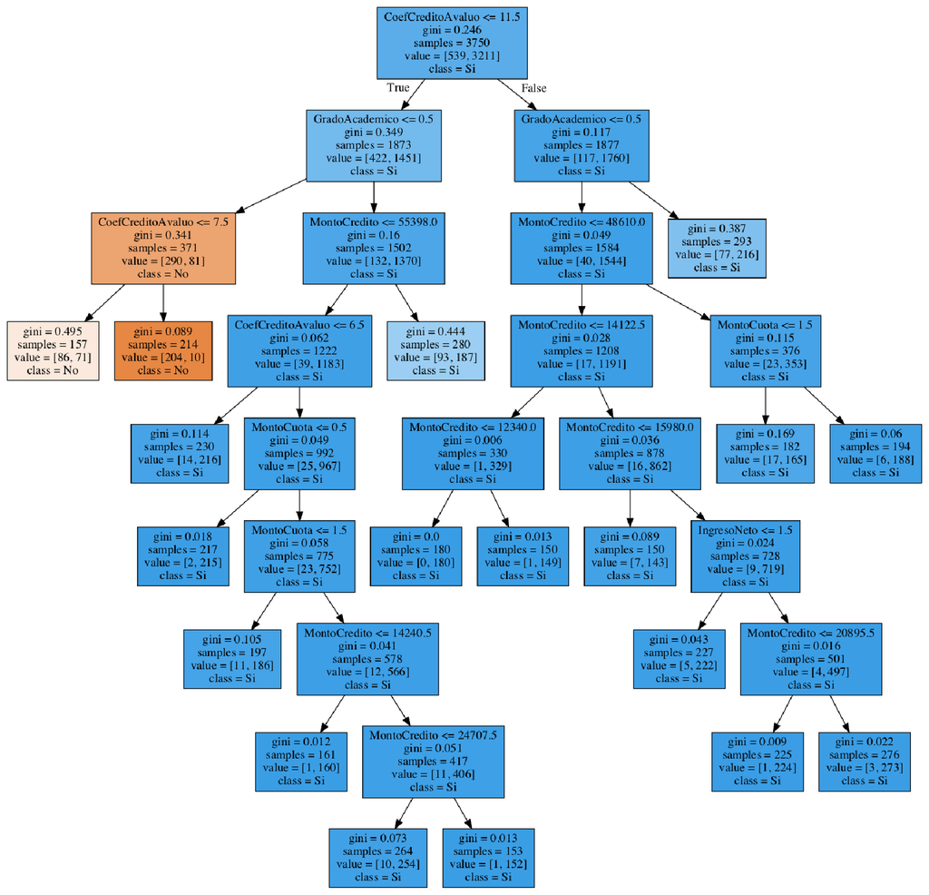

```python
datos_plotear = export_graphviz(instancia_arbol2, out_file=None,class_names=["No", "Si"],
                feature_names=list(X.columns.values), filled=True)
grafico = graphviz.Source(datos_plotear)
plt.rcParams['figure.figsize'] = [30, 30] # Tamaño del gráfico
graficar_arbol(grafico)
```

## Ejemplo con SAHeart.csv

```python
os.chdir("/Users/oldemarrodriguez/Google Drive/MDCurso/Datos")
print(os.getcwd())
datos = pd.read_csv('SAheart.csv',delimiter=';',decimal=".")
print(datos.shape)
print(datos.info())
print(datos.head())
# Convierte las variables de object a categórica
datos['famhist'] = datos['famhist'].astype('category')
print(datos.info())
print(datos.head())
# Recodifica las categorías usando números
datos["famhist"] = datos["famhist"].cat.codes
print(datos.info())
print(datos.head())
# Convierte las variables de entero a categórica
datos['famhist'] = datos['famhist'].astype('category')
print(datos.info())
print(datos.head())
```

```
/Users/oldemarrodriguez/Google Drive/MDCurso/Datos
(462, 10)
<class 'pandas.core.frame.DataFrame'>
RangeIndex: 462 entries, 0 to 461
Data columns (total 10 columns):
sbp          462 non-null int64
tobacco      462 non-null float64
ldl          462 non-null float64
adiposity    462 non-null float64
famhist      462 non-null object
typea        462 non-null int64
obesity      462 non-null float64
alcohol      462 non-null float64
age          462 non-null int64
chd          462 non-null object
dtypes: float64(5), int64(3), object(2)
memory usage: 36.2+ KB
None
   sbp  tobacco   ldl  adiposity  famhist  typea  obesity  alcohol  age chd
0  160    12.00  5.73      23.11  Present     49    25.30    97.20   52  Si
1  144     0.01  4.41      28.61   Absent     55    28.87     2.06   63  Si
2  118     0.08  3.48      32.28  Present     52    29.14     3.81   46  No
3  170     7.50  6.41      38.03  Present     51    31.99    24.26   58  Si
4  134    13.60  3.50      27.78  Present     60    25.99    57.34   49  Si
<class 'pandas.core.frame.DataFrame'>
RangeIndex: 462 entries, 0 to 461
Data columns (total 10 columns):
sbp          462 non-null int64
tobacco      462 non-null float64
ldl          462 non-null float64
adiposity    462 non-null float64
famhist      462 non-null category
typea        462 non-null int64
obesity      462 non-null float64
alcohol      462 non-null float64
age          462 non-null int64
chd          462 non-null object
dtypes: category(1), float64(5), int64(3), object(1)
memory usage: 33.2+ KB
None
```

[output cut: 35 more lines]

```
famhist      462 non-null category
typea        462 non-null int64
obesity      462 non-null float64
alcohol      462 non-null float64
age          462 non-null int64
chd          462 non-null object
dtypes: category(1), float64(5), int64(3), object(1)
memory usage: 33.2+ KB
None
   sbp  tobacco   ldl  adiposity famhist  typea  obesity  alcohol  age chd
0  160    12.00  5.73      23.11       1     49    25.30    97.20   52  Si
1  144     0.01  4.41      28.61       0     55    28.87     2.06   63  Si
2  118     0.08  3.48      32.28       1     52    29.14     3.81   46  No
3  170     7.50  6.41      38.03       1     51    31.99    24.26   58  Si
4  134    13.60  3.50      27.78       1     60    25.99    57.34   49  Si
```

### Equilibrio de la variable a predecir

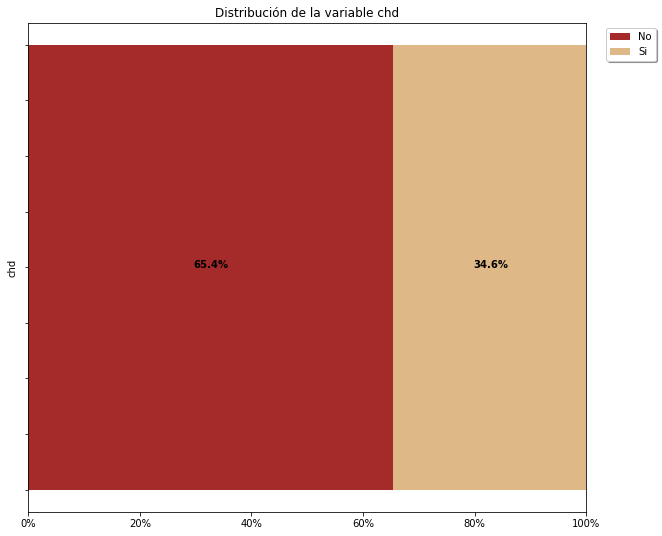

```python
distribucion_variable_predecir(datos,"chd")
```

### Genera el modelo, las predicciones y mide la calidad

```python
X = datos.iloc[:,:9]
print(X.head())

y = datos.iloc[:,9:10]
print(y.head())

X_train, X_test, y_train, y_test = train_test_split(X, y, train_size=0.80, random_state=0)

instancia_arbol = DecisionTreeClassifier()

instancia_arbol.fit(X_train,y_train)

prediccion = instancia_arbol.predict(X_test)
MC = confusion_matrix(y_test, prediccion)

indices = indices_general(MC,list(np.unique(y)))
for k in indices:
    print("\n%s:\n%s"%(k,str(indices[k])))
```

```
   sbp  tobacco   ldl  adiposity famhist  typea  obesity  alcohol  age
0  160    12.00  5.73      23.11       1     49    25.30    97.20   52
1  144     0.01  4.41      28.61       0     55    28.87     2.06   63
2  118     0.08  3.48      32.28       1     52    29.14     3.81   46
3  170     7.50  6.41      38.03       1     51    31.99    24.26   58
4  134    13.60  3.50      27.78       1     60    25.99    57.34   49
  chd
0  Si
1  Si
2  No
3  Si
4  Si

Matriz de Confusión:
[[48 13]
 [11 21]]

Precisión Global:
0.7419354838709677

Error Global:
0.25806451612903225

Precisión por categoría:
         No       Si
0  0.786885  0.65625
```

### Graficar el árbol

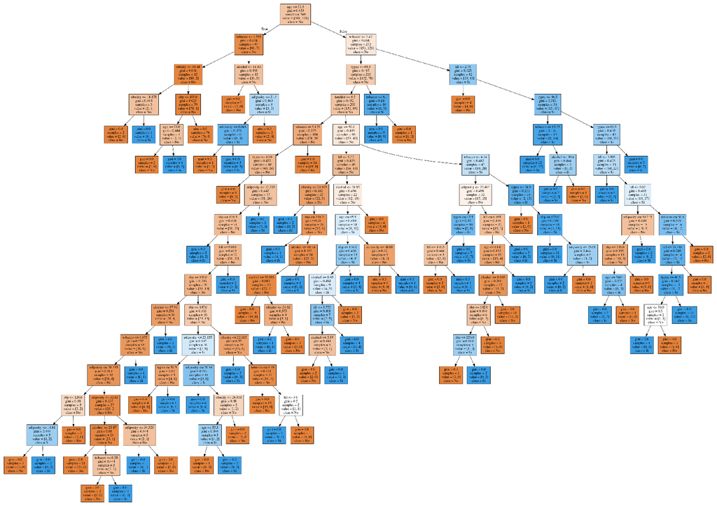

```python
datos_plotear = export_graphviz(instancia_arbol, out_file=None,class_names=["No", "Si"],
                feature_names=list(X.columns.values), filled=True)
grafico = graphviz.Source(datos_plotear)
plt.rcParams['figure.figsize'] = [30, 30] # Tamaño del gráfico
graficar_arbol(grafico)
```

### Selección de variables

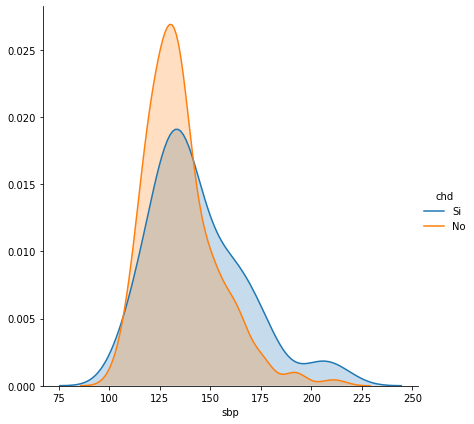

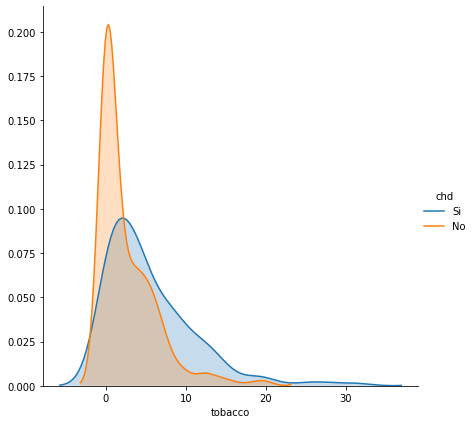

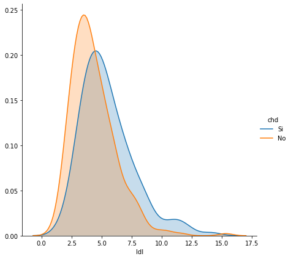

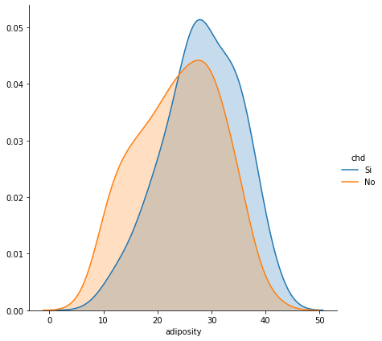

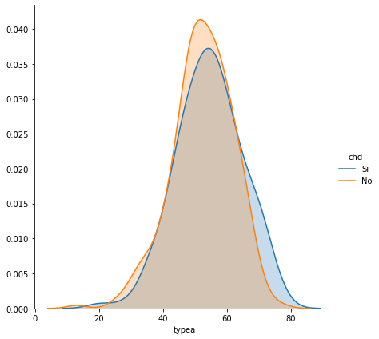

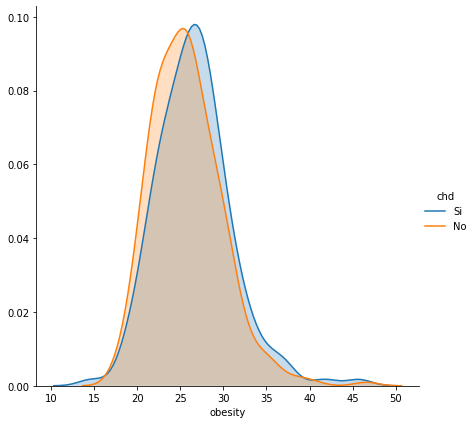

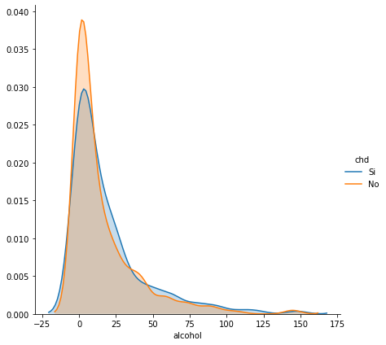

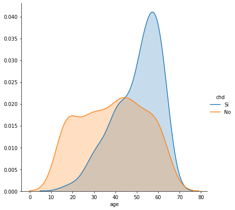

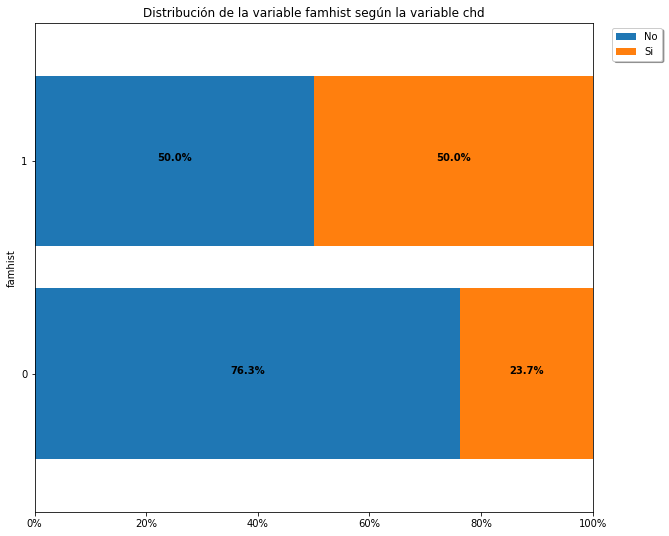

```python
poder_predictivo_numerica(datos,"sbp","chd")
poder_predictivo_numerica(datos,"tobacco","chd")
poder_predictivo_numerica(datos,"ldl","chd")
poder_predictivo_numerica(datos,"adiposity","chd")
poder_predictivo_numerica(datos,"typea","chd")
poder_predictivo_numerica(datos,"obesity","chd")
poder_predictivo_numerica(datos,"alcohol","chd")
poder_predictivo_numerica(datos,"age","chd")
poder_predictivo_categorica(datos,"famhist","chd")
```

```python
X = datos.iloc[:,[2,4,8]]
print(X.head())
y = datos.iloc[:,9:10]
print(y.head())
```

```
    ldl famhist  age
0  5.73       1   52
1  4.41       0   63
2  3.48       1   46
3  6.41       1   58
4  3.50       1   49
  chd
0  Si
1  Si
2  No
3  Si
4  Si
```

#### Genera el modelo predictivo, las predicciones y mide la calidad

```python
# Con el 80% de los datos para entrenamiento
X_train, X_test, y_train, y_test = train_test_split(X, y, train_size=0.80, random_state=0)

instancia_arbol2 = DecisionTreeClassifier()

instancia_arbol2.fit(X_train,y_train)

prediccion = instancia_arbol2.predict(X_test)
MC = confusion_matrix(y_test, prediccion)

indices = indices_general(MC,list(np.unique(y)))
for k in indices:
    print("\n%s:\n%s"%(k,str(indices[k])))
```

```
Matriz de Confusión:
[[39 22]
 [20 12]]

Precisión Global:
0.5483870967741935

Error Global:
0.4516129032258065

Precisión por categoría:
         No     Si
0  0.639344  0.375
```

### Graficar el árbol

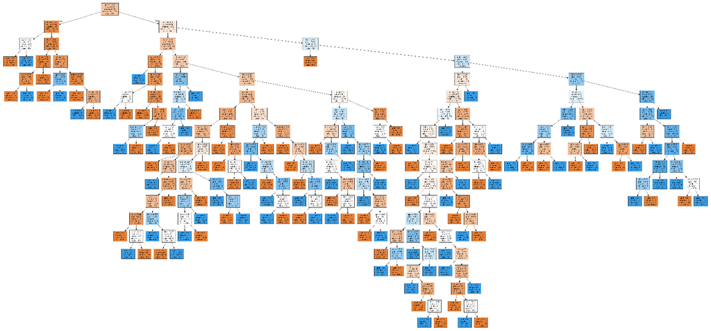

```python
datos_plotear = export_graphviz(instancia_arbol2, out_file=None,class_names=["No", "Si"],
                feature_names=list(X.columns.values), filled=True)
grafico = graphviz.Source(datos_plotear)
plt.rcParams['figure.figsize'] = [30, 30] # Tamaño del gráfico
graficar_arbol(grafico)
```